# T1

Armando Arredondo Valle

19/5/2022

# Personalizando nuestra sesión

```r
knitr::opts_chunk$set(echo = TRUE)

options(digits=3,papersize = "letter")
# https://stat.ethz.ch/R-manual/R-devel/library/base/html/options.html


# Opciones globales en graficas
par(mar=c(5.1,5,4.1,2.1),font=3,family="sans",bg="yellow")

# En R existen varios conjuntos de datos:

# install.packages("datasets.load")
# datasets.load::alldata()   # O bien library(datasets.load); alldata()

# data(package = .packages(all.available = TRUE))
# Si marca error en la version de "htmltools", instalarlo de nuevo.
# R sugerira el reinicio de su sesion, aceptarla.
```

# Problema a estudiar

Se tienen las mediciones de la calidad diaria del aire en la ciudad de Nueva York desde Mayo hasta Septiembre de 1973.

Las variables que se registraron son:

- Ozone: medición del ozono en partes por billón (ppb) en la isla de Roosevelt La medición de la concentración de ozono en el aire se puede efectuar mediante diferentes técnicas e instrumental como los monitores automáticos de absorción ultravioleta.
- Solar.R: radiación solar (en Langleys) medida en la banda de frecuencia de 4000-7700 Angstroms al mediodía en Central Park.
- Wind: velocidad media del viento (mph) entre las 7-10 am en el aeropuerto de LaGuardia.
- Temp: temperatura máxima diaria (en °F)
- Month numeric Month (1–12)
- Day numeric Day of month (1–31) ## Lectura y manejo de datos

Antes de realizar el análisis estadístico más adecuado es conveniente revisar:

1. Que la información de todas las variables sea completa
2. Que nuestra elección esté de acuerdo con el tipo de variable y su escala de medición para ¡no meter la pata!

```r
library(datasets)
data("airquality")   # ver el conjunto de datos de interes

datos1<- airquality  # para guardarlos como objeto

head(datos1)    # ver los primeros 6 renglones del conjunto de datos
```

```
##   Ozone Solar.R Wind Temp Month Day
## 1    41     190  7.4   67     5   1
## 2    36     118  8.0   72     5   2
## 3    12     149 12.6   74     5   3
## 4    18     313 11.5   62     5   4
## 5    NA      NA 14.3   56     5   5
## 6    28      NA 14.9   66     5   6
```

```r
tail(datos1)    # ver los ultimos 6 renglones del conjunto de datos
```

```
##     Ozone Solar.R Wind Temp Month Day
## 148    14      20 16.6   63     9  25
## 149    30     193  6.9   70     9  26
## 150    NA     145 13.2   77     9  27
## 151    14     191 14.3   75     9  28
## 152    18     131  8.0   76     9  29
## 153    20     223 11.5   68     9  30
```

```r
dim(datos1)
```

```
## [1] 153   6
```

```r
names(datos1)
```

```
## [1] "Ozone"   "Solar.R" "Wind"    "Temp"    "Month"   "Day"
```

```r
str(datos1)
```

```
## 'data.frame':    153 obs. of  6 variables:
##  $ Ozone  : int  41 36 12 18 NA 28 23 19 8 NA ...
##  $ Solar.R: int  190 118 149 313 NA NA 299 99 19 194 ...
##  $ Wind   : num  7.4 8 12.6 11.5 14.3 14.9 8.6 13.8 20.1 8.6 ...
##  $ Temp   : int  67 72 74 62 56 66 65 59 61 69 ...
##  $ Month  : int  5 5 5 5 5 5 5 5 5 5 ...
##  $ Day    : int  1 2 3 4 5 6 7 8 9 10 ...
```

```r
mode(datos1)
```

```
## [1] "list"
```

```r
# Exploremos algunas variables

datos1$Temp   # llamamos a la variable "Temp"
```

```
##   [1] 67 72 74 62 56 66 65 59 61 69 74 69 66 68 58 64 66 57 68 62 59 73 61 61 57
##  [26] 58 57 67 81 79 76 78 74 67 84 85 79 82 87 90 87 93 92 82 80 79 77 72 65 73
##  [51] 76 77 76 76 76 75 78 73 80 77 83 84 85 81 84 83 83 88 92 92 89 82 73 81 91
##  [76] 80 81 82 84 87 85 74 81 82 86 85 82 86 88 86 83 81 81 81 82 86 85 87 89 90
## [101] 90 92 86 86 82 80 79 77 79 76 78 78 77 72 75 79 81 86 88 97 94 96 94 91 92
## [126] 93 93 87 84 80 78 75 73 81 76 77 71 71 78 67 76 68 82 64 71 81 69 63 70 77
## [151] 75 76 68
```

```r
datos1[,3] # da la columna 3
```

```
##   [1]  7.4  8.0 12.6 11.5 14.3 14.9  8.6 13.8 20.1  8.6  6.9  9.7  9.2 10.9 13.2
##  [16] 11.5 12.0 18.4 11.5  9.7  9.7 16.6  9.7 12.0 16.6 14.9  8.0 12.0 14.9  5.7
##  [31]  7.4  8.6  9.7 16.1  9.2  8.6 14.3  9.7  6.9 13.8 11.5 10.9  9.2  8.0 13.8
##  [46] 11.5 14.9 20.7  9.2 11.5 10.3  6.3  1.7  4.6  6.3  8.0  8.0 10.3 11.5 14.9
##  [61]  8.0  4.1  9.2  9.2 10.9  4.6 10.9  5.1  6.3  5.7  7.4  8.6 14.3 14.9 14.9
##  [76] 14.3  6.9 10.3  6.3  5.1 11.5  6.9  9.7 11.5  8.6  8.0  8.6 12.0  7.4  7.4
##  [91]  7.4  9.2  6.9 13.8  7.4  6.9  7.4  4.6  4.0 10.3  8.0  8.6 11.5 11.5 11.5
## [106]  9.7 11.5 10.3  6.3  7.4 10.9 10.3 15.5 14.3 12.6  9.7  3.4  8.0  5.7  9.7
## [121]  2.3  6.3  6.3  6.9  5.1  2.8  4.6  7.4 15.5 10.9 10.3 10.9  9.7 14.9 15.5
## [136]  6.3 10.9 11.5  6.9 13.8 10.3 10.3  8.0 12.6  9.2 10.3 10.3 16.6  6.9 13.2
## [151] 14.3  8.0 11.5
```

```r
datos1[3,] # da el renglon 3
```

```
##   Ozone Solar.R Wind Temp Month Day
## 3    12     149 12.6   74     5   3
```

```r
datos1[1:10,3:6]  # para seleccionar una parte de los datos
```

```
##    Wind Temp Month Day
## 1   7.4   67     5   1
## 2   8.0   72     5   2
## 3  12.6   74     5   3
## 4  11.5   62     5   4
## 5  14.3   56     5   5
## 6  14.9   66     5   6
## 7   8.6   65     5   7
## 8  13.8   59     5   8
## 9  20.1   61     5   9
## 10  8.6   69     5  10
```

```r
# COMENTARIO: Si llamamos a la variable solo por su nombre, es decir, Temp y luego operamos con ella, por ejemplo, Temp+12
# MARCARA ERROR AL TEJER!

# Solucion.....

attach(datos1) # con el attach ya puedo accesar a los nombres de las variables

Temp
```

```
##   [1] 67 72 74 62 56 66 65 59 61 69 74 69 66 68 58 64 66 57 68 62 59 73 61 61 57
##  [26] 58 57 67 81 79 76 78 74 67 84 85 79 82 87 90 87 93 92 82 80 79 77 72 65 73
##  [51] 76 77 76 76 76 75 78 73 80 77 83 84 85 81 84 83 83 88 92 92 89 82 73 81 91
##  [76] 80 81 82 84 87 85 74 81 82 86 85 82 86 88 86 83 81 81 81 82 86 85 87 89 90
## [101] 90 92 86 86 82 80 79 77 79 76 78 78 77 72 75 79 81 86 88 97 94 96 94 91 92
## [126] 93 93 87 84 80 78 75 73 81 76 77 71 71 78 67 76 68 82 64 71 81 69 63 70 77
## [151] 75 76 68
```

```r
(Temp-32)*(5/9)  # Centigrados
```

```
##   [1] 19.4 22.2 23.3 16.7 13.3 18.9 18.3 15.0 16.1 20.6 23.3 20.6 18.9 20.0 14.4
##  [16] 17.8 18.9 13.9 20.0 16.7 15.0 22.8 16.1 16.1 13.9 14.4 13.9 19.4 27.2 26.1
##  [31] 24.4 25.6 23.3 19.4 28.9 29.4 26.1 27.8 30.6 32.2 30.6 33.9 33.3 27.8 26.7
##  [46] 26.1 25.0 22.2 18.3 22.8 24.4 25.0 24.4 24.4 24.4 23.9 25.6 22.8 26.7 25.0
##  [61] 28.3 28.9 29.4 27.2 28.9 28.3 28.3 31.1 33.3 33.3 31.7 27.8 22.8 27.2 32.8
##  [76] 26.7 27.2 27.8 28.9 30.6 29.4 23.3 27.2 27.8 30.0 29.4 27.8 30.0 31.1 30.0
##  [91] 28.3 27.2 27.2 27.2 27.8 30.0 29.4 30.6 31.7 32.2 32.2 33.3 30.0 30.0 27.8
## [106] 26.7 26.1 25.0 26.1 24.4 25.6 25.6 25.0 22.2 23.9 26.1 27.2 30.0 31.1 36.1
## [121] 34.4 35.6 34.4 32.8 33.3 33.9 33.9 30.6 28.9 26.7 25.6 23.9 22.8 27.2 24.4
## [136] 25.0 21.7 21.7 25.6 19.4 24.4 20.0 27.8 17.8 21.7 27.2 20.6 17.2 21.1 25.0
## [151] 23.9 24.4 20.0
```

```r
# OJO: el problema con attach es que si manejo 2 o mas bases de datos
# distintas, y estas comparten el mismo nombre de las columnas, R se
# hace bolas y no sabra exactamente a que base de datos se refiere.

#detach(datos1) # para decirle a R que ya NO usare esa base de datos
```

Antes de realizar el análisis descriptivo, limpiemos, ordenemos y cambiemos el nombre de las variables.

```r
library(dplyr)
datos1<- select(datos1, Month, Day, Ozone, Temp, Solar.R, Wind)

#        NUEVO                 # ANTERIOR
datos2<- rename(datos1, Ozono       = Ozone,
       Radiacion  = Solar.R,
       Viento     = Wind,
       Temperatura= Temp,
       Mes        = Month,
       Dia        = Day)

names(datos2)
```

```
## [1] "Mes"         "Dia"         "Ozono"       "Temperatura" "Radiacion"
## [6] "Viento"
```

```r
attach(datos2)  # para que reconozca las variables solo por su nombre,
                # de lo contrario hay que escribir datos2$Viento
```

Revisión “rápida” del conjunto de datos:

```r
# install.packages("skimr")
skimr::skim(datos2)
```

Data summary

| Name | datos2 |
| --- | --- |
| Number of rows | 153 |
| Number of columns | 6 |
| _______________________ |  |
| Column type frequency: |  |
| numeric | 6 |
| ________________________ |  |
| Group variables | None |

**Variable type: numeric**

| skim_variable | n_missing | complete_rate | mean | sd | p0 | p25 | p50 | p75 | p100 | hist |
| --- | --- | --- | --- | --- | --- | --- | --- | --- | --- | --- |
| Mes | 0 | 1.00 | 6.99 | 1.42 | 5.0 | 6.0 | 7.0 | 8.0 | 9.0 | ▇▇▇▇▇ |
| Dia | 0 | 1.00 | 15.80 | 8.86 | 1.0 | 8.0 | 16.0 | 23.0 | 31.0 | ▇▇▇▇▆ |
| Ozono | 37 | 0.76 | 42.13 | 32.99 | 1.0 | 18.0 | 31.5 | 63.2 | 168.0 | ▇▃▂▁▁ |
| Temperatura | 0 | 1.00 | 77.88 | 9.47 | 56.0 | 72.0 | 79.0 | 85.0 | 97.0 | ▂▃▇▇▃ |
| Radiacion | 7 | 0.95 | 185.93 | 90.06 | 7.0 | 115.8 | 205.0 | 258.8 | 334.0 | ▅▃▅▇▅ |
| Viento | 0 | 1.00 | 9.96 | 3.52 | 1.7 | 7.4 | 9.7 | 11.5 | 20.7 | ▂▇▇▃▁ |

| Velocidad del viento (km/h) | Descripción EU |
| --- | --- |
| $0-1$ | Calma |
| $2-5$ | Ventolina |
| $6-11$ | Brisa suave |
| $12-19$ | Brisa ligera |
| $20-28$ | Brisa moderada |
| $29-38$ | Brisa fresca |
| $39-49$ | Brisa fuerte |
| $50-61$ | Viento fuerte |
| $62-74$ | Viento duro |
| $75-88$ | Viento muy duro |
| $89-102$ | Temporal |
| $103-117$ | Temporal muy duro (borrasca) |
| $> 118$ | Huracán |

```r
TipoViento <- NA
TipoViento[Viento >= 0 & Viento <= 1.6093] <- "Calma"
TipoViento[Viento > 1.6093 & Viento <= 1.6093*5] <- "Ventolina"
TipoViento[Viento > 1.6093*5 & Viento <= 1.6093*11] <- "Brisa suave"
TipoViento[Viento > 1.6093*11 & Viento <= 1.6093*19] <- "Brisa ligera"
TipoViento[Viento > 1.6093*19 & Viento <= 1.6093*28] <- "Brisa moderada"
TipoViento[Viento > 1.6093*28 & Viento <= 1.6093*38] <- "Brisa fresca"

TipoViento
```

```
##   [1] "Ventolina"    "Ventolina"    "Brisa suave"  "Brisa suave"  "Brisa suave"
##   [6] "Brisa suave"  "Brisa suave"  "Brisa suave"  "Brisa ligera" "Brisa suave"
##  [11] "Ventolina"    "Brisa suave"  "Brisa suave"  "Brisa suave"  "Brisa suave"
##  [16] "Brisa suave"  "Brisa suave"  "Brisa ligera" "Brisa suave"  "Brisa suave"
##  [21] "Brisa suave"  "Brisa suave"  "Brisa suave"  "Brisa suave"  "Brisa suave"
##  [26] "Brisa suave"  "Ventolina"    "Brisa suave"  "Brisa suave"  "Ventolina"
##  [31] "Ventolina"    "Brisa suave"  "Brisa suave"  "Brisa suave"  "Brisa suave"
##  [36] "Brisa suave"  "Brisa suave"  "Brisa suave"  "Ventolina"    "Brisa suave"
##  [41] "Brisa suave"  "Brisa suave"  "Brisa suave"  "Ventolina"    "Brisa suave"
##  [46] "Brisa suave"  "Brisa suave"  "Brisa ligera" "Brisa suave"  "Brisa suave"
##  [51] "Brisa suave"  "Ventolina"    "Ventolina"    "Ventolina"    "Ventolina"
##  [56] "Ventolina"    "Ventolina"    "Brisa suave"  "Brisa suave"  "Brisa suave"
##  [61] "Ventolina"    "Ventolina"    "Brisa suave"  "Brisa suave"  "Brisa suave"
##  [66] "Ventolina"    "Brisa suave"  "Ventolina"    "Ventolina"    "Ventolina"
##  [71] "Ventolina"    "Brisa suave"  "Brisa suave"  "Brisa suave"  "Brisa suave"
```

[output cut: 16 more lines]

```r
# Ahora si ordenamos las columnas
datos2<- cbind(datos2,TipoViento)

datos<- select(datos2, Mes, Ozono)  # library(dplyr)

head(datos)
```

```
##   Mes Ozono
## 1   5    41
## 2   5    36
## 3   5    12
## 4   5    18
## 5   5    NA
## 6   5    28
```

Examinemos si hay datos faltantes.

```r
library(naniar)
pct_miss(datos2)
```

```
## [1] 4.11
```

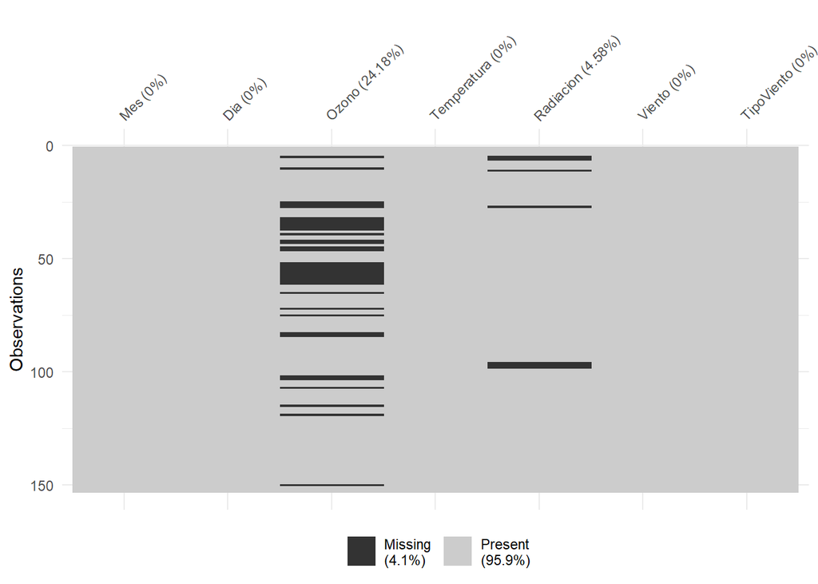

```r
vis_miss(datos2)
```

## Tipo de variable y escala de medición

### Identificación de las variables

| Variable | Tipo | Escala de medición |
| --- | --- | --- |
| Mes | cualitativa | nominal |
| Dia | cualitativa | nominal |
| Ozono | cuantitativa/continua | razón |
| Temperatura | cuantitativa/continua | intervalo |
| Radiacion | cuantitativa/continua | razón |
| Viento | cuantitativa/continua | razón |
| TipoViento | cualitativa | ordinal |